# `summarize()`, `tabyl()`, and `group_by()`

2021-01-21

## Learning Goals

*At the end of this exercise, you will be able to:*  
1. Use a combination of `select()`, `filter()`, and `mutate()` to transform data frames.  
2. Use the `skimr` package to produce summaries of data.  
3. Produce clean summaries of data using `summarize()`.  
4. Use `group_by()` in combination with `summarize()` to produce grouped summaries of data.

## Review

At this point, you should be comfortable using the functions of `dplyr`. If you need extra help, please email me.

## Package updates

In order to use some of the new function in the second part of lab today, you need to update your installed R packages. Please navigate to `Tools` >`Check for Package Updates...`. Follow the directions to update the packages.

## Load the tidyverse and janitor

```r
library("tidyverse")
library("janitor")
```

## Install `skimr`

```r
#install.packages("skimr")
library("skimr")
```

## Load the data

For this lab, we will use the built-in data on mammal sleep patterns. From: *V. M. Savage and G. B. West. A quantitative, theoretical framework for understanding mammalian sleep. Proceedings of the National Academy of Sciences, 104 (3):1051-1056, 2007*.

```r
?msleep
names(msleep)
```

```
##  [1] "name"         "genus"        "vore"         "order"        "conservation"
##  [6] "sleep_total"  "sleep_rem"    "sleep_cycle"  "awake"        "brainwt"
## [11] "bodywt"
```

```r
#Remember, ? before a command will tell you what it is!
```

We will also use the awesome [palmerpenguins](https://allisonhorst.github.io/palmerpenguins/articles/intro.html) data in the second part of lab so let’s install it now.

```r
remotes::install_github("allisonhorst/palmerpenguins")
```

## dplyr Practice

1. Let’s do a bit more practice to make sure that we understand `select()`, `filter()`, and `mutate()`. Start by building a new data frame `msleep24` from the `msleep` data that: contains the `name` and `vore` variables along with a new column called `sleep_total_24` which is the amount of time a species sleeps expressed as a proportion of a 24-hour day. Remove any rows with NA’s and restrict the `sleep_total_24` values to less than 0.3. Arrange the output in descending order.

```r
#Original code I used. It didn't work for histograms or tabyl because the NAs weren't taken out properly. It will look for the string NA, not the values:
#msleep24 <- msleep %>%
#  mutate(sleep_total_24=sleep_total/24) %>%
#  select(name, vore, sleep_total_24) %>%
#  filter(name !="NA", vore !="NA", sleep_total_24 !="NA") %>%
#  filter(sleep_total_24 < "0.3") %>%
#  arrange(desc(sleep_total_24))
```

```r
msleep24 <- msleep %>%
  mutate(sleep_total_24=sleep_total/24) %>%
  select(name, vore, sleep_total_24) %>%
  filter(!is.na(vore)) %>%
  filter(sleep_total_24 < 0.3) %>%
  arrange(desc(sleep_total_24))
```

Did `dplyr` do what we expected? How do we check our output? Remember, just because your code runs it doesn’t mean that it did what you intended.

```r
summary(msleep24)
```

```
##      name               vore           sleep_total_24
##  Length:18          Length:18          Min.   :0.07917
##  Class :character   Class :character   1st Qu.:0.13125
##  Mode  :character   Mode  :character   Median :0.16458
##                                        Mean   :0.17755
##                                        3rd Qu.:0.22083
##                                        Max.   :0.26250
```

Try out the new function `skim()` as part of the `skimr` package.

```r
skim(msleep24)
```

Data summary

| Name | msleep24 |
| --- | --- |
| Number of rows | 18 |
| Number of columns | 3 |
| _______________________ |  |
| Column type frequency: |  |
| character | 2 |
| numeric | 1 |
| ________________________ |  |
| Group variables | None |

**Variable type: character**

| skim_variable | n_missing | complete_rate | min | max | empty | n_unique | whitespace |
| --- | --- | --- | --- | --- | --- | --- | --- |
| name | 0 | 1 | 3 | 20 | 0 | 18 | 0 |
| vore | 0 | 1 | 5 | 5 | 0 | 2 | 0 |

**Variable type: numeric**

| skim_variable | n_missing | complete_rate | mean | sd | p0 | p25 | p50 | p75 | p100 | hist |
| --- | --- | --- | --- | --- | --- | --- | --- | --- | --- | --- |
| sleep_total_24 | 0 | 1 | 0.18 | 0.06 | 0.08 | 0.13 | 0.16 | 0.22 | 0.26 | ▃▇▆▅▆ |

Histograms are also a quick way to check the output.

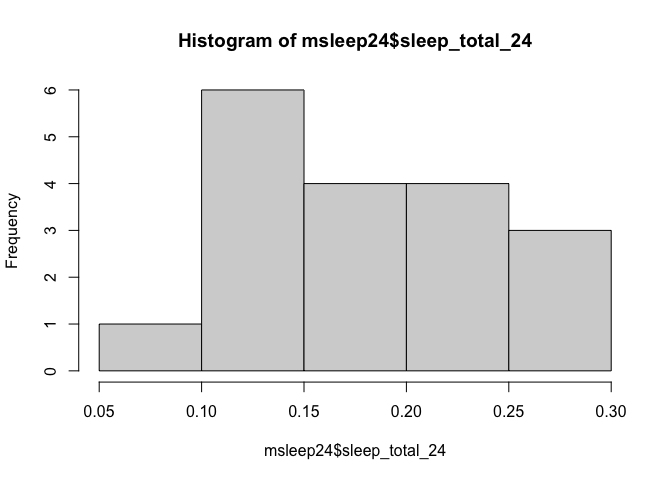

```r
hist(msleep24$sleep_total_24)
```

Gives you idea of adjustment of variables.

Don’t forget we can also use `tabyl()` across one or many variables.

```r
msleep24 %>%
  tabyl(vore) %>%
  adorn_pct_formatting(digits=1)
```

```
##   vore  n percent
##  carni  6   33.3%
##  herbi 12   66.7%
```

```r
  #Adorn changes formating of how the percentages are shown
```

## Practice

1. Which taxonomic orders have species that belong to more than one class of `vore`?

```r
names(msleep24)
```

```
## [1] "name"           "vore"           "sleep_total_24"
```

```r
msleep %>%
  tabyl(vore)
```

```
##     vore  n    percent valid_percent
##    carni 19 0.22891566    0.25000000
##    herbi 32 0.38554217    0.42105263
##  insecti  5 0.06024096    0.06578947
##     omni 20 0.24096386    0.26315789
##     <NA>  7 0.08433735            NA
```

```r
#Valid percent: dealing with NAs a little bit. Considering there are NAs, take care of that in advance in the next code chunk:
```

```r
msleep %>%
  filter(!is.na(vore)) %>%
  tabyl(order, vore)
```

```
##            order carni herbi insecti omni
##     Afrosoricida     0     0       0    1
##     Artiodactyla     0     5       0    1
##        Carnivora    12     0       0    0
##          Cetacea     3     0       0    0
##       Chiroptera     0     0       2    0
##        Cingulata     1     0       1    0
##  Didelphimorphia     1     0       0    1
##    Diprotodontia     0     1       0    0
##   Erinaceomorpha     0     0       0    1
##       Hyracoidea     0     2       0    0
##       Lagomorpha     0     1       0    0
##      Monotremata     0     0       1    0
##   Perissodactyla     0     3       0    0
##           Pilosa     0     1       0    0
##         Primates     1     1       0   10
##      Proboscidea     0     2       0    0
##         Rodentia     1    16       0    2
##       Scandentia     0     0       0    1
##     Soricomorpha     0     0       1    3
```

```r
#You can simply arrange data table by changing order you insert, ex. tabyl(vore, order)
```

## `summarize()`

`summarize()` will produce summary statistics for a given variable in a data frame. For example, if you are asked to calculate the mean of `sleep_total` for large and small mammals you could do this using a combination of commands, but it isn’t very efficient or clean. We can do better!

```r
head(msleep)
```

```
## # A tibble: 6 x 11
##   name  genus vore  order conservation sleep_total sleep_rem sleep_cycle awake
##   <chr> <chr> <chr> <chr> <chr>              <dbl>     <dbl>       <dbl> <dbl>
## 1 Chee… Acin… carni Carn… lc                  12.1      NA        NA      11.9
## 2 Owl … Aotus omni  Prim… <NA>                17         1.8      NA       7
## 3 Moun… Aplo… herbi Rode… nt                  14.4       2.4      NA       9.6
## 4 Grea… Blar… omni  Sori… lc                  14.9       2.3       0.133   9.1
## 5 Cow   Bos   herbi Arti… domesticated         4         0.7       0.667  20
## 6 Thre… Brad… herbi Pilo… <NA>                14.4       2.2       0.767   9.6
## # … with 2 more variables: brainwt <dbl>, bodywt <dbl>
```

```r
#Looking for sleep total variable
```

For example, if we define “large” as having a `bodywt` greater than 200 then we get the following:

```r
large <- msleep %>%
  select(name, genus, bodywt, sleep_total) %>%
  filter(bodywt > 200) %>%
  arrange(desc(bodywt))
large
```

```
## # A tibble: 7 x 4
##   name             genus         bodywt sleep_total
##   <chr>            <chr>          <dbl>       <dbl>
## 1 African elephant Loxodonta      6654          3.3
## 2 Asian elephant   Elephas        2547          3.9
## 3 Giraffe          Giraffa         900.         1.9
## 4 Pilot whale      Globicephalus   800          2.7
## 5 Cow              Bos             600          4
## 6 Horse            Equus           521          2.9
## 7 Brazilian tapir  Tapirus         208.         4.4
```

```r
mean(large$sleep_total)
```

```
## [1] 3.3
```

We can accomplish the same task using the `summarize()` function to make things cleaner.

```r
msleep %>%
  filter(bodywt > 200) %>%
  summarize(mean_sleep_lg = mean(sleep_total))
```

```
## # A tibble: 1 x 1
##   mean_sleep_lg
##           <dbl>
## 1           3.3
```

```r
#First call dataframe. Pipe to filters (so restricting yourself to large animals). Then use summarize. The first part is giving a name to the new variable you're producing. This will equal the mean of sleep_total
```

You can also combine functions to make useful summaries for multiple variables.

```r
msleep %>%
    filter(bodywt > 200) %>%
    summarize(mean_sleep_lg = mean(sleep_total),
              min_sleep_lg = min(sleep_total),
              max_sleep_lg = max(sleep_total),
              total = n())
```

```
## # A tibble: 1 x 4
##   mean_sleep_lg min_sleep_lg max_sleep_lg total
##           <dbl>        <dbl>        <dbl> <int>
## 1           3.3          1.9          4.4     7
```

## Practice

1. What is the mean, min, and max `bodywt` for the taxonomic order Primates? Provide the total number of observations.

```r
msleep %>%
    filter(order=="Primates") %>%
    summarize(mean_bodywt = mean(bodywt),
              min_bodywt = min(bodywt),
              max_bodywt = max(bodywt),
              n_samples=n())
```

```
## # A tibble: 1 x 4
##   mean_bodywt min_bodywt max_bodywt n_samples
##         <dbl>      <dbl>      <dbl>     <int>
## 1        13.9        0.2         62        12
```

```r
dim(msleep)
```

```
## [1] 83 11
```

`n_distinct()` is a very handy way of cleanly presenting the number of distinct observations. Here we show the number of distinct genera over 100 in body weight. (This is the number of distinct observations. In this case, asking for the number of distinct genera. There are 9, so likely multiple species within a single genus)

```r
msleep %>%
  filter(bodywt > 100) %>%
  summarise(n_genera=n_distinct(genus))
```

```
## # A tibble: 1 x 1
##   n_genera
##      <int>
## 1        9
```

There are many other useful summary statistics, depending on your needs: sd(), min(), max(), median(), sum(), n() (returns the length of a column), first() (returns first value in a column), last() (returns last value in a column) and n_distinct() (number of distinct values in a column).

## Practice

1. How many genera are represented in the msleep data frame?

```r
msleep %>%
  summarise(n_genera=n_distinct(genus))
```

```
## # A tibble: 1 x 1
##   n_genera
##      <int>
## 1       77
```

2. What are the min, max, and mean `sleep_total` for all of the mammals? Be sure to include the total n.

```r
msleep %>%
    summarize(min_sleep_total = min(sleep_total),
              max_sleep_total = max(sleep_total),
              mean_sleep_total = mean(sleep_total),
              n_samples=n())
```

```
## # A tibble: 1 x 4
##   min_sleep_total max_sleep_total mean_sleep_total n_samples
##             <dbl>           <dbl>            <dbl>     <int>
## 1             1.9            19.9             10.4        83
```

## `group_by()`

The `summarize()` function is most useful when used in conjunction with `group_by()`. Although producing a summary of body weight for all of the mammals in the data set is helpful, what if we were interested in body weight by feeding ecology (vore, in this case)?

Always but group_by first, then do the summarize:

```r
msleep %>%
  group_by(vore) %>% #we are grouping by feeding ecology
  summarize(min_bodywt = min(bodywt),
            max_bodywt = max(bodywt),
            mean_bodywt = mean(bodywt),
            total=n())
```

```
## # A tibble: 5 x 5
##   vore    min_bodywt max_bodywt mean_bodywt total
## * <chr>        <dbl>      <dbl>       <dbl> <int>
## 1 carni        0.028      800        90.8      19
## 2 herbi        0.022     6654       367.       32
## 3 insecti      0.01        60        12.9       5
## 4 omni         0.005       86.2      12.7      20
## 5 <NA>         0.021        3.6       0.858     7
```

## Practice

1. Calculate mean brain weight by taxonomic order in the msleep data.

```r
names(msleep)
```

```
##  [1] "name"         "genus"        "vore"         "order"        "conservation"
##  [6] "sleep_total"  "sleep_rem"    "sleep_cycle"  "awake"        "brainwt"
## [11] "bodywt"
```

```r
msleep %>%
  group_by(order) %>%
  summarize(mean_brainwt= mean(brainwt))
```

```
## # A tibble: 19 x 2
##    order           mean_brainwt
##  * <chr>                  <dbl>
##  1 Afrosoricida        0.0026
##  2 Artiodactyla       NA
##  3 Carnivora          NA
##  4 Cetacea            NA
##  5 Chiroptera          0.000275
##  6 Cingulata           0.0459
##  7 Didelphimorphia    NA
##  8 Diprotodontia      NA
##  9 Erinaceomorpha      0.00295
## 10 Hyracoidea          0.0152
## 11 Lagomorpha          0.0121
## 12 Monotremata         0.025
## 13 Perissodactyla      0.414
## 14 Pilosa             NA
## 15 Primates           NA
## 16 Proboscidea         5.16
## 17 Rodentia           NA
## 18 Scandentia          0.0025
## 19 Soricomorpha        0.000592
```

```r
#Summarize/summarise = same thing
```

2. What does `NA` mean? How are NA’s being treated by the summarize function?

```r
msleep %>%
  filter(order=="Carnivora") %>%
  select(order, brainwt)
```

```
## # A tibble: 12 x 2
##    order     brainwt
##    <chr>       <dbl>
##  1 Carnivora NA
##  2 Carnivora NA
##  3 Carnivora  0.07
##  4 Carnivora  0.0256
##  5 Carnivora  0.325
##  6 Carnivora NA
##  7 Carnivora  0.157
##  8 Carnivora NA
##  9 Carnivora NA
## 10 Carnivora  0.0175
## 11 Carnivora  0.0445
## 12 Carnivora  0.0504
```

So some observations are present, other are not. Examining this in more detail:

```r
msleep %>%
  filter(order=="Carnivora") %>%
  select(order, genus, brainwt)
```

```
## # A tibble: 12 x 3
##    order     genus        brainwt
##    <chr>     <chr>          <dbl>
##  1 Carnivora Acinonyx     NA
##  2 Carnivora Callorhinus  NA
##  3 Carnivora Canis         0.07
##  4 Carnivora Felis         0.0256
##  5 Carnivora Haliochoerus  0.325
##  6 Carnivora Panthera     NA
##  7 Carnivora Panthera      0.157
##  8 Carnivora Panthera     NA
##  9 Carnivora Phoca        NA
## 10 Carnivora Genetta       0.0175
## 11 Carnivora Vulpes        0.0445
## 12 Carnivora Vulpes        0.0504
```

So some genus brainwts haven’t been measured. We want to make sure we deal with the NAs correctly going forward. We do this by removing any NAs:

3. Try running the code again, but this time add `na.rm=TRUE`. What is the problem with Cetacea? Compare this to Carnivora.

```r
msleep %>%
  group_by(order) %>%
  summarize(mean_brainwt= mean(brainwt, na.rm=T))
```

```
## # A tibble: 19 x 2
##    order           mean_brainwt
##  * <chr>                  <dbl>
##  1 Afrosoricida        0.0026
##  2 Artiodactyla        0.198
##  3 Carnivora           0.0986
##  4 Cetacea           NaN
##  5 Chiroptera          0.000275
##  6 Cingulata           0.0459
##  7 Didelphimorphia     0.0063
##  8 Diprotodontia       0.0114
##  9 Erinaceomorpha      0.00295
## 10 Hyracoidea          0.0152
## 11 Lagomorpha          0.0121
## 12 Monotremata         0.025
## 13 Perissodactyla      0.414
## 14 Pilosa            NaN
## 15 Primates            0.254
## 16 Proboscidea         5.16
## 17 Rodentia            0.00357
## 18 Scandentia          0.0025
## 19 Soricomorpha        0.000592
```

NaN = different type of NA. Cetacea includes things like whales, so not so much a mystery to why we haven’t measured thier brain weight.

```r
msleep %>%
  filter(order=="Cetacea") %>%
  select(order, genus, brainwt)
```

```
## # A tibble: 3 x 3
##   order   genus         brainwt
##   <chr>   <chr>           <dbl>
## 1 Cetacea Globicephalus      NA
## 2 Cetacea Phocoena           NA
## 3 Cetacea Tursiops           NA
```

So the reason why we get NaN is because we have no data for Cetaceans in our dataframe.

## That’s it! Take a break and I will see you on Zoom!

–>[Home](https://jmledford3115.github.io/datascibiol/)